# Kavitha_Assignment4

## Objective:

The classification goal is to predict if the client will subscribe (yes/no) a term deposit (variable y).

## Steps and tasks:

1. Import the necessary libraries
2. Read the data as a data frame
3. Perform basic EDA which should include the following and print out your insights at every step. a. Shape of the data b. Data type of each attribute c. Checking the presence of missing values d. 5 point summary of numerical attributes e. Checking the presence of outliers
4. Prepare the data to train a model – check if data types are appropriate, get rid of the missing values etc
5. Train a few standard classification algorithms, note and comment on their performances along different metrics.
6. Build the ensemble models and compare the results with the base models. Note: Random forest can be used only with Decision trees.
7. Compare performances of all the models

```python
%matplotlib inline
```

```python
import numpy as np
import pandas as pd
from matplotlib import pyplot as plt
import seaborn as sns
import warnings
warnings.filterwarnings('ignore')
from scipy.stats import zscore
```

```python
colnames = ['age', 'job', 'marital', 'education', 'default', 'balance', 'housing', 'loan', 'contact', 'day', 'month', 'duration', 'campaign', 'pdays', 'previous', 'poutcome', 'Target']
df = pd.read_csv('bank-full.csv')
df.head(30)
```

|  | age | job | marital | education | default | balance | housing | loan | contact | day | month | duration | campaign | pdays | previous | poutcome | Target |
| --- | --- | --- | --- | --- | --- | --- | --- | --- | --- | --- | --- | --- | --- | --- | --- | --- | --- |
| 0 | 58 | management | married | tertiary | no | 2143 | yes | no | unknown | 5 | may | 261 | 1 | -1 | 0 | unknown | no |
| 1 | 44 | technician | single | secondary | no | 29 | yes | no | unknown | 5 | may | 151 | 1 | -1 | 0 | unknown | no |
| 2 | 33 | entrepreneur | married | secondary | no | 2 | yes | yes | unknown | 5 | may | 76 | 1 | -1 | 0 | unknown | no |
| 3 | 47 | blue-collar | married | unknown | no | 1506 | yes | no | unknown | 5 | may | 92 | 1 | -1 | 0 | unknown | no |
| 4 | 33 | unknown | single | unknown | no | 1 | no | no | unknown | 5 | may | 198 | 1 | -1 | 0 | unknown | no |
| 5 | 35 | management | married | tertiary | no | 231 | yes | no | unknown | 5 | may | 139 | 1 | -1 | 0 | unknown | no |
| 6 | 28 | management | single | tertiary | no | 447 | yes | yes | unknown | 5 | may | 217 | 1 | -1 | 0 | unknown | no |
| 7 | 42 | entrepreneur | divorced | tertiary | yes | 2 | yes | no | unknown | 5 | may | 380 | 1 | -1 | 0 | unknown | no |
| 8 | 58 | retired | married | primary | no | 121 | yes | no | unknown | 5 | may | 50 | 1 | -1 | 0 | unknown | no |
| 9 | 43 | technician | single | secondary | no | 593 | yes | no | unknown | 5 | may | 55 | 1 | -1 | 0 | unknown | no |
| 10 | 41 | admin. | divorced | secondary | no | 270 | yes | no | unknown | 5 | may | 222 | 1 | -1 | 0 | unknown | no |
| 11 | 29 | admin. | single | secondary | no | 390 | yes | no | unknown | 5 | may | 137 | 1 | -1 | 0 | unknown | no |
| 12 | 53 | technician | married | secondary | no | 6 | yes | no | unknown | 5 | may | 517 | 1 | -1 | 0 | unknown | no |
| 13 | 58 | technician | married | unknown | no | 71 | yes | no | unknown | 5 | may | 71 | 1 | -1 | 0 | unknown | no |
| 14 | 57 | services | married | secondary | no | 162 | yes | no | unknown | 5 | may | 174 | 1 | -1 | 0 | unknown | no |
| 15 | 51 | retired | married | primary | no | 229 | yes | no | unknown | 5 | may | 353 | 1 | -1 | 0 | unknown | no |
| 16 | 45 | admin. | single | unknown | no | 13 | yes | no | unknown | 5 | may | 98 | 1 | -1 | 0 | unknown | no |
| 17 | 57 | blue-collar | married | primary | no | 52 | yes | no | unknown | 5 | may | 38 | 1 | -1 | 0 | unknown | no |
| 18 | 60 | retired | married | primary | no | 60 | yes | no | unknown | 5 | may | 219 | 1 | -1 | 0 | unknown | no |
| 19 | 33 | services | married | secondary | no | 0 | yes | no | unknown | 5 | may | 54 | 1 | -1 | 0 | unknown | no |
| 20 | 28 | blue-collar | married | secondary | no | 723 | yes | yes | unknown | 5 | may | 262 | 1 | -1 | 0 | unknown | no |
| 21 | 56 | management | married | tertiary | no | 779 | yes | no | unknown | 5 | may | 164 | 1 | -1 | 0 | unknown | no |
| 22 | 32 | blue-collar | single | primary | no | 23 | yes | yes | unknown | 5 | may | 160 | 1 | -1 | 0 | unknown | no |
| 23 | 25 | services | married | secondary | no | 50 | yes | no | unknown | 5 | may | 342 | 1 | -1 | 0 | unknown | no |
| 24 | 40 | retired | married | primary | no | 0 | yes | yes | unknown | 5 | may | 181 | 1 | -1 | 0 | unknown | no |
| 25 | 44 | admin. | married | secondary | no | -372 | yes | no | unknown | 5 | may | 172 | 1 | -1 | 0 | unknown | no |
| 26 | 39 | management | single | tertiary | no | 255 | yes | no | unknown | 5 | may | 296 | 1 | -1 | 0 | unknown | no |
| 27 | 52 | entrepreneur | married | secondary | no | 113 | yes | yes | unknown | 5 | may | 127 | 1 | -1 | 0 | unknown | no |
| 28 | 46 | management | single | secondary | no | -246 | yes | no | unknown | 5 | may | 255 | 2 | -1 | 0 | unknown | no |
| 29 | 36 | technician | single | secondary | no | 265 | yes | yes | unknown | 5 | may | 348 | 1 | -1 | 0 | unknown | no |

```python
df.shape # Shape of the data
```

```
(45211, 17)
```

```python
df.info() # Data Types of the data
```

```
<class 'pandas.core.frame.DataFrame'>
RangeIndex: 45211 entries, 0 to 45210
Data columns (total 17 columns):
age          45211 non-null int64
job          45211 non-null object
marital      45211 non-null object
education    45211 non-null object
default      45211 non-null object
balance      45211 non-null int64
housing      45211 non-null object
loan         45211 non-null object
contact      45211 non-null object
day          45211 non-null int64
month        45211 non-null object
duration     45211 non-null int64
campaign     45211 non-null int64
pdays        45211 non-null int64
previous     45211 non-null int64
poutcome     45211 non-null object
Target       45211 non-null object
dtypes: int64(7), object(10)
memory usage: 4.1+ MB
```

# Checking the presence of missing values

```python
df.isnull().values.any()
```

```
False
```

There are no missing values in the dataset. However we could see few features like 'unknown' & 'others' for few columns. This may be the missing values or outliers. This data will not be much helpful.

```python
# Delete the rows which column 'poutcome' contains 'other'
other = df.poutcome == 'other'
df1 = df.drop(df[other].index, axis = 0, inplace = False)

# Step 2: Fill 'unknown' in job and education to 'other'
df1[['job','education']] = df1[['job','education']].replace(['unknown'],'other')

df1.head(30)
```

|  | age | job | marital | education | default | balance | housing | loan | contact | day | month | duration | campaign | pdays | previous | poutcome | Target |
| --- | --- | --- | --- | --- | --- | --- | --- | --- | --- | --- | --- | --- | --- | --- | --- | --- | --- |
| 0 | 58 | management | married | tertiary | no | 2143 | yes | no | unknown | 5 | may | 261 | 1 | -1 | 0 | unknown | no |
| 1 | 44 | technician | single | secondary | no | 29 | yes | no | unknown | 5 | may | 151 | 1 | -1 | 0 | unknown | no |
| 2 | 33 | entrepreneur | married | secondary | no | 2 | yes | yes | unknown | 5 | may | 76 | 1 | -1 | 0 | unknown | no |
| 3 | 47 | blue-collar | married | other | no | 1506 | yes | no | unknown | 5 | may | 92 | 1 | -1 | 0 | unknown | no |
| 4 | 33 | other | single | other | no | 1 | no | no | unknown | 5 | may | 198 | 1 | -1 | 0 | unknown | no |
| 5 | 35 | management | married | tertiary | no | 231 | yes | no | unknown | 5 | may | 139 | 1 | -1 | 0 | unknown | no |
| 6 | 28 | management | single | tertiary | no | 447 | yes | yes | unknown | 5 | may | 217 | 1 | -1 | 0 | unknown | no |
| 7 | 42 | entrepreneur | divorced | tertiary | yes | 2 | yes | no | unknown | 5 | may | 380 | 1 | -1 | 0 | unknown | no |
| 8 | 58 | retired | married | primary | no | 121 | yes | no | unknown | 5 | may | 50 | 1 | -1 | 0 | unknown | no |
| 9 | 43 | technician | single | secondary | no | 593 | yes | no | unknown | 5 | may | 55 | 1 | -1 | 0 | unknown | no |
| 10 | 41 | admin. | divorced | secondary | no | 270 | yes | no | unknown | 5 | may | 222 | 1 | -1 | 0 | unknown | no |
| 11 | 29 | admin. | single | secondary | no | 390 | yes | no | unknown | 5 | may | 137 | 1 | -1 | 0 | unknown | no |
| 12 | 53 | technician | married | secondary | no | 6 | yes | no | unknown | 5 | may | 517 | 1 | -1 | 0 | unknown | no |
| 13 | 58 | technician | married | other | no | 71 | yes | no | unknown | 5 | may | 71 | 1 | -1 | 0 | unknown | no |
| 14 | 57 | services | married | secondary | no | 162 | yes | no | unknown | 5 | may | 174 | 1 | -1 | 0 | unknown | no |
| 15 | 51 | retired | married | primary | no | 229 | yes | no | unknown | 5 | may | 353 | 1 | -1 | 0 | unknown | no |
| 16 | 45 | admin. | single | other | no | 13 | yes | no | unknown | 5 | may | 98 | 1 | -1 | 0 | unknown | no |
| 17 | 57 | blue-collar | married | primary | no | 52 | yes | no | unknown | 5 | may | 38 | 1 | -1 | 0 | unknown | no |
| 18 | 60 | retired | married | primary | no | 60 | yes | no | unknown | 5 | may | 219 | 1 | -1 | 0 | unknown | no |
| 19 | 33 | services | married | secondary | no | 0 | yes | no | unknown | 5 | may | 54 | 1 | -1 | 0 | unknown | no |
| 20 | 28 | blue-collar | married | secondary | no | 723 | yes | yes | unknown | 5 | may | 262 | 1 | -1 | 0 | unknown | no |
| 21 | 56 | management | married | tertiary | no | 779 | yes | no | unknown | 5 | may | 164 | 1 | -1 | 0 | unknown | no |
| 22 | 32 | blue-collar | single | primary | no | 23 | yes | yes | unknown | 5 | may | 160 | 1 | -1 | 0 | unknown | no |
| 23 | 25 | services | married | secondary | no | 50 | yes | no | unknown | 5 | may | 342 | 1 | -1 | 0 | unknown | no |
| 24 | 40 | retired | married | primary | no | 0 | yes | yes | unknown | 5 | may | 181 | 1 | -1 | 0 | unknown | no |
| 25 | 44 | admin. | married | secondary | no | -372 | yes | no | unknown | 5 | may | 172 | 1 | -1 | 0 | unknown | no |
| 26 | 39 | management | single | tertiary | no | 255 | yes | no | unknown | 5 | may | 296 | 1 | -1 | 0 | unknown | no |
| 27 | 52 | entrepreneur | married | secondary | no | 113 | yes | yes | unknown | 5 | may | 127 | 1 | -1 | 0 | unknown | no |
| 28 | 46 | management | single | secondary | no | -246 | yes | no | unknown | 5 | may | 255 | 2 | -1 | 0 | unknown | no |
| 29 | 36 | technician | single | secondary | no | 265 | yes | yes | unknown | 5 | may | 348 | 1 | -1 | 0 | unknown | no |

# 5 point summary of numerical attributes & Checking the presence of outliers

```python
df1.info(), df1.describe()
```

```
<class 'pandas.core.frame.DataFrame'>
Int64Index: 43371 entries, 0 to 45209
Data columns (total 17 columns):
age          43371 non-null int64
job          43371 non-null object
marital      43371 non-null object
education    43371 non-null object
default      43371 non-null object
balance      43371 non-null int64
housing      43371 non-null object
loan         43371 non-null object
contact      43371 non-null object
day          43371 non-null int64
month        43371 non-null object
duration     43371 non-null int64
campaign     43371 non-null int64
pdays        43371 non-null int64
previous     43371 non-null int64
poutcome     43371 non-null object
Target       43371 non-null object
dtypes: int64(7), object(10)
memory usage: 4.3+ MB
```

```
(None,
                 age        balance           day      duration      campaign  \
 count  43371.000000   43371.000000  43371.000000  43371.000000  43371.000000
 mean      40.986443    1356.963063     15.862904    258.266930      2.776671
 std       10.595454    3030.956348      8.324122    257.950498      3.138053
 min       18.000000   -8019.000000      1.000000      0.000000      1.000000
 25%       33.000000      70.000000      8.000000    103.000000      1.000000
 50%       39.000000     443.000000     16.000000    180.000000      2.000000
 75%       48.000000    1417.000000     21.000000    318.000000      3.000000
 max       95.000000  102127.000000     31.000000   4918.000000     63.000000

               pdays      previous
 count  43371.000000  43371.000000
 mean      32.158954      0.434853
 std       90.689195      1.559405
 min       -1.000000      0.000000
 25%       -1.000000      0.000000
 50%       -1.000000      0.000000
 75%       -1.000000      0.000000
 max      871.000000     55.000000  )
```

From the above description on dataset, we can see the 5 point summary on each variables. We can see that the variable Balance consists of more outliers.

The outliers need to br dropped now. Outliers are defined as the values which are more than three standard deviations away from the mean. zscore can be used for this.

```python
df1[['balance']].mean()

df1['balance_outliers'] = df1['balance']
df1['balance_outliers']= zscore(df1['balance_outliers'])

condition1 = (df1['balance_outliers']>3) | (df1['balance_outliers']<-3 )
df2 = df1.drop(df1[condition1].index, axis = 0, inplace = False)
bank_df = df2.drop('balance_outliers', axis=1)
bank_df.info(), bank_df.describe()
```

```
<class 'pandas.core.frame.DataFrame'>
Int64Index: 42655 entries, 0 to 45209
Data columns (total 17 columns):
age          42655 non-null int64
job          42655 non-null object
marital      42655 non-null object
education    42655 non-null object
default      42655 non-null object
balance      42655 non-null int64
housing      42655 non-null object
loan         42655 non-null object
contact      42655 non-null object
day          42655 non-null int64
month        42655 non-null object
duration     42655 non-null int64
campaign     42655 non-null int64
pdays        42655 non-null int64
previous     42655 non-null int64
poutcome     42655 non-null object
Target       42655 non-null object
dtypes: int64(7), object(10)
memory usage: 4.2+ MB
```

```
(None,
                 age       balance           day      duration     campaign  \
 count  42655.000000  42655.000000  42655.000000  42655.000000  42655.00000
 mean      40.937123   1079.808416     15.863299    258.173157      2.77808
 std       10.578167   1717.623768      8.329445    257.847671      3.14056
 min       18.000000  -6847.000000      1.000000      0.000000      1.00000
 25%       33.000000     66.000000      8.000000    103.000000      1.00000
 50%       39.000000    425.000000     16.000000    180.000000      2.00000
 75%       48.000000   1341.000000     21.000000    318.000000      3.00000
 max       95.000000  10443.000000     31.000000   4918.000000     63.00000

               pdays      previous
 count  42655.000000  42655.000000
 mean      32.210855      0.434885
 std       90.856368      1.563589
 min       -1.000000      0.000000
 25%       -1.000000      0.000000
 50%       -1.000000      0.000000
 75%       -1.000000      0.000000
 max      871.000000     55.000000  )
```

# Data Visualisation:

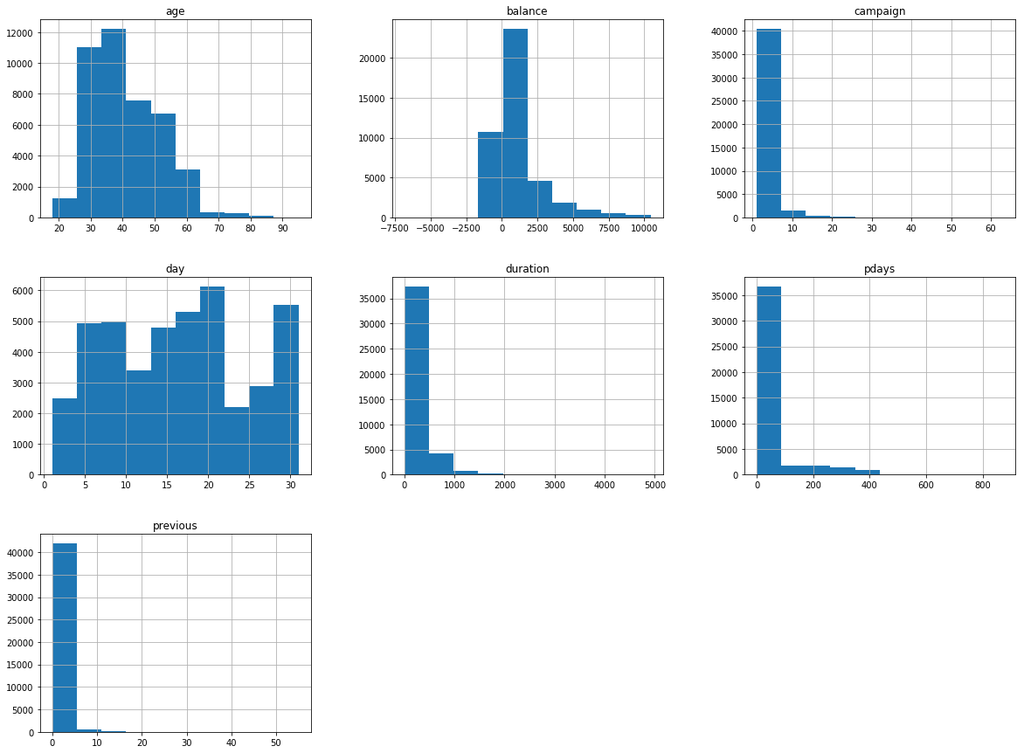

```python
bank_df.hist(figsize=(20, 15))
plt.show()
```

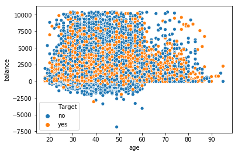

```python
# Lets see the relation between other variables with the target variable
sns.scatterplot(x='age',y='balance',hue='Target',data=bank_df)
```

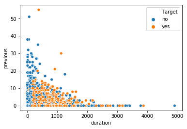

```python
sns.scatterplot(x='duration',y='previous',hue='Target',data=bank_df)
```

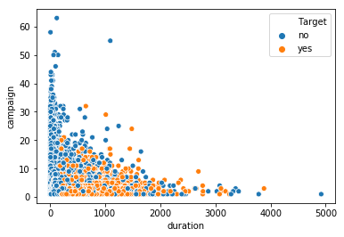

```python
sns.scatterplot(x='duration',y='campaign',hue='Target',data=bank_df)
```

From the above graphs, we can interpret for each variables.

Balance: After dropping outliers in balance, the range of balance is still massive, from a minimum of -6847 to a maximum of 10443 euros, giving a range of 17290 euros. The distribution of balance has a huge standard deviation relative to the mean, suggesting large variabilities in customers' balance levels.

From the graph between campaign (number of calls made) vs duration, we can see that the clients have subscribed with less number of calls. With increase in number of calls, there is no much subscription. This should also be noted as more of number calls might result in losing the clients.

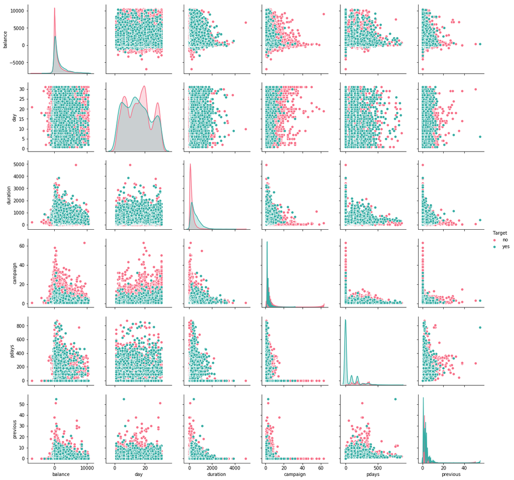

```python
sns.pairplot(bank_df.iloc[:,1:], hue="Target", palette="husl")
```

```python
corr = bank_df.corr()
corr
```

|  | age | balance | day | duration | campaign | pdays | previous |
| --- | --- | --- | --- | --- | --- | --- | --- |
| age | 1.000000 | 0.105504 | -0.010668 | -0.006064 | 0.004580 | -0.006096 | 0.014026 |
| balance | 0.105504 | 1.000000 | 0.009472 | 0.035927 | -0.022389 | 0.016910 | 0.038031 |
| day | -0.010668 | 0.009472 | 1.000000 | -0.032865 | 0.169848 | -0.088887 | -0.055350 |
| duration | -0.006064 | 0.035927 | -0.032865 | 1.000000 | -0.083199 | 0.000181 | 0.005692 |
| campaign | 0.004580 | -0.022389 | 0.169848 | -0.083199 | 1.000000 | -0.094046 | -0.051426 |
| pdays | -0.006096 | 0.016910 | -0.088887 | 0.000181 | -0.094046 | 1.000000 | 0.568111 |
| previous | 0.014026 | 0.038031 | -0.055350 | 0.005692 | -0.051426 | 0.568111 | 1.000000 |

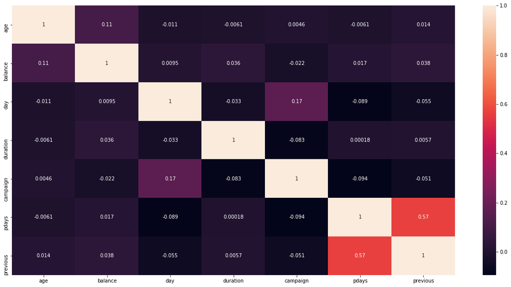

```python
plt.figure(figsize=(20,10))
sns.heatmap(corr,annot=True)
```

From the pairplots, we can see that there is no clear relationship between the variables age, balance, duration and campaign.

# Transformation of Data

```python
bank_df.dtypes
```

```
age           int64
job          object
marital      object
education    object
default      object
balance       int64
housing      object
loan         object
contact      object
day           int64
month        object
duration      int64
campaign      int64
pdays         int64
previous      int64
poutcome     object
Target       object
dtype: object
```

```python
# Classfication models, Decision tree in Python can take only numerical / categorical colums. It cannot take string / object types.
# The following code loops through each column and checks if the column type is object then converts those columns
# into categorical with each distinct value becoming a category or code.

for feature in df.columns: # Loop through all columns in the dataframe
    if bank_df[feature].dtype == 'object': # Only apply for columns with categorical strings
        bank_df[feature] = pd.Categorical(bank_df[feature]).codes # Replace strings with an integer

bank_df.info(), bank_df.describe()
```

```
<class 'pandas.core.frame.DataFrame'>
Int64Index: 42655 entries, 0 to 45209
Data columns (total 17 columns):
age          42655 non-null int64
job          42655 non-null int8
marital      42655 non-null int8
education    42655 non-null int8
default      42655 non-null int8
balance      42655 non-null int64
housing      42655 non-null int8
loan         42655 non-null int8
contact      42655 non-null int8
day          42655 non-null int64
month        42655 non-null int8
duration     42655 non-null int64
campaign     42655 non-null int64
pdays        42655 non-null int64
previous     42655 non-null int64
poutcome     42655 non-null int8
Target       42655 non-null int8
dtypes: int64(7), int8(10)
memory usage: 4.0 MB
```

```
(None,
                 age           job       marital     education       default  \
 count  42655.000000  42655.000000  42655.000000  42655.000000  42655.000000
 mean      40.937123      4.693565      1.165092      2.054882      0.018685
 std       10.578167      3.667607      0.607301      0.778312      0.135411
 min       18.000000      0.000000      0.000000      0.000000      0.000000
 25%       33.000000      1.000000      1.000000      2.000000      0.000000
 50%       39.000000      4.000000      1.000000      2.000000      0.000000
 75%       48.000000      8.000000      2.000000      3.000000      0.000000
 max       95.000000     11.000000      2.000000      3.000000      1.000000

             balance       housing          loan       contact           day  \
 count  42655.000000  42655.000000  42655.000000  42655.000000  42655.000000
 mean    1079.808416      0.553909      0.162724      0.663627     15.863299
 std     1717.623768      0.497091      0.369118      0.907936      8.329445
 min    -6847.000000      0.000000      0.000000      0.000000      1.000000
 25%       66.000000      0.000000      0.000000      0.000000      8.000000
 50%      425.000000      1.000000      0.000000      0.000000     16.000000
 75%     1341.000000      1.000000      0.000000      2.000000     21.000000
 max    10443.000000      1.000000      1.000000      2.000000     31.000000

               month      duration     campaign         pdays      previous  \
 count  42655.000000  42655.000000  42655.00000  42655.000000  42655.000000
 mean       5.515743    258.173157      2.77808     32.210855      0.434885
 std        2.983698    257.847671      3.14056     90.856368      1.563589
 min        0.000000      0.000000      1.00000     -1.000000      0.000000
 25%        3.000000    103.000000      1.00000     -1.000000      0.000000
 50%        6.000000    180.000000      2.00000     -1.000000      0.000000
 75%        8.000000    318.000000      3.00000     -1.000000      0.000000
 max       11.000000   4918.000000     63.00000    871.000000     55.000000

            poutcome        Target
 count  42655.000000  42655.000000
 mean       1.739210      0.114172
 std        0.647392      0.318024
 min        0.000000      0.000000
 25%        2.000000      0.000000
 50%        2.000000      0.000000
 75%        2.000000      0.000000
 max        2.000000      1.000000  )
```

# Splitting of Data into Training and Test Datasets:

For splitting the data into training and test sets, we need to separate the Dependent and independent (Target) variables into two different data frames.

Since contact has no impact in the dataset, lets drop the column contact in our datasets.

Here our target variable is Target. All other variables are dependant variables.

```python
from sklearn.model_selection import train_test_split # # Import Sklearn package's data splitting function
from sklearn import metrics
from sklearn import preprocessing

X = bank_df.drop(['contact','Target'], axis=1)
y = bank_df['Target']

# Split X and y into training and test set in 70:30 ratio

X_train, X_test, y_train, y_test = train_test_split(X, y, test_size=0.3, random_state=10)
```

# Scaling of data to improve the accuracy:

```python
## To have an accurate score, let us create another set of data with scaling function applied to it.

ZX = preprocessing.scale(X)
ZX_train, ZX_test, y_train, y_test = train_test_split(ZX, y, test_size=0.3, random_state=10)
```

# Logistic Regression Model:

```python
from sklearn.linear_model import LogisticRegression # Import Logistic Regression machine learning library
log_model1 = LogisticRegression()

# Apply training data to the logistic regression model
log_model1.fit(X_train, y_train)

#Predict the test results
y_predict = log_model1.predict(X_test)
```

```python
# Let us explore the coefficients for each of the independent attributes

for idx, col_name in enumerate(X_train.columns):
    print("The coefficient for {} is {}".format(col_name, log_model1.coef_[0][idx]))
```

```
The coefficient for age is 0.0014283369734405975
The coefficient for job is 0.014647979337141522
The coefficient for marital is 0.17064297721197144
The coefficient for education is 0.16003271853648332
The coefficient for default is -0.17109315275329287
The coefficient for balance is 6.0627382940197484e-05
The coefficient for housing is -1.1554743466607877
The coefficient for loan is -0.6536197800851996
The coefficient for day is -0.0029304159176130723
The coefficient for month is -0.014876770894916888
The coefficient for duration is 0.0039035339019349176
The coefficient for campaign is -0.14934103262832693
The coefficient for pdays is 0.0033063406381144997
The coefficient for previous is 0.14300655950772528
The coefficient for poutcome is 0.08120967079814602
```

```python
# Let us check the intercept for the model

intercept = log_model1.intercept_[0]

print("The intercept for our model is {}".format(intercept))
```

```
The intercept for our model is -3.378233093912698
```

```python
# Calculate the model score and print confusion matrix

log_model1_score = log_model1.score(X_test, y_test)
print("The Logistic Regression model accuracy is {}".format(log_model1_score))
```

```
The Logistic Regression model accuracy is 0.8925529420958037
```

```python
print("The confustion matrix for Logistic Regression is")
print(metrics.confusion_matrix(y_test, y_predict))
```

```
The confustion matrix for Logistic Regression is
[[11085   213]
 [ 1162   337]]
```

From the confusion matrix results, we can see the below observations.

True negative is 11085 & True postive is 337. False postive is 213 & False negative is 1162.

```python
# Apply Scaled training data to the logistic regression model
log_model2 = LogisticRegression()
log_model2.fit(ZX_train, y_train)

#Predict the test results
y_predict1 = log_model2.predict(ZX_test)

# Let us explore the coefficients for each of the independent attributes

coef_df = pd.DataFrame(log_model2.coef_)
print(coef_df)
```

```
         0         1         2         3         4         5         6   \
0  0.050629  0.058488  0.138561  0.145507 -0.023177  0.105199 -0.570217

         7         8         9         10        11        12        13  \
0 -0.237797 -0.015602 -0.034043  1.012215 -0.460128  0.343839  0.236877

         14
0  0.113163
```

```python
# Let us check the intercept for the model

intercept1 = log_model2.intercept_[0]
print("The intercept for Logistic Regression model is {}".format(intercept1))
```

```
The intercept for Logistic Regression model is -2.641615846547623
```

```python
# Calculate the model score

log_model2_score = log_model2.score(ZX_test, y_test)
print("The Logistic Regression model accuracy with scaled data is {}".format(log_model2_score))
```

```
The Logistic Regression model accuracy with scaled data is 0.8923185121512854
```

```python
# Print confusion matrix

print("The confustion matrix for Logistic Regression with scaled data is")
print(metrics.confusion_matrix(y_test, y_predict1))
```

```
The confustion matrix for Logistic Regression with scaled data is
[[11081   217]
 [ 1161   338]]
```

```python
# Print confusion matrix

print("The confustion matrix for Logistic Regression with scaled data is")
print(metrics.confusion_matrix(y_test, y_predict1))
```

```
The confustion matrix for Logistic Regression with scaled data is
[[11081   217]
 [ 1161   338]]
```

False Postive is 217 & False nrgative is 1161.

The Logistic regression score is almost equal before and after scaling.

# Naive Bayes Model:

```python
from sklearn.naive_bayes import GaussianNB

naive_model1 = GaussianNB()
naive_model1.fit(X_train,y_train)
y_predict_naive = naive_model1.predict(X_test)
naive_model1_score = naive_model1.score(X_test, y_test)
print("The Naive Bayes model accuracy is {}".format(naive_model1_score))
print(metrics.confusion_matrix(y_test, y_predict_naive))
```

```
The Naive Bayes model accuracy is 0.8387121981714465
[[10072  1226]
 [  838   661]]
```

The Naive Bayes model accuracy is 83.87%

False Postive is 1226 & False negative is 838.

```python
naive_model2 = GaussianNB()
naive_model2.fit(ZX_train,y_train)
y_predict1_naive = naive_model2.predict(ZX_test)
naive_model2_score = naive_model2.score(ZX_test, y_test)
print("The Naive Bayes model accuracy is {}".format(naive_model2_score))
print(metrics.confusion_matrix(y_test, y_predict1_naive))
```

```
The Naive Bayes model accuracy is 0.837696335078534
[[10053  1245]
 [  832   667]]
```

Now the Naive Bayes model accuracy with scaled dataset is 83.76%

False Postive is 1245 & False negative is 832.

Naive Bayes Model accuracy is almost same before and after scaling.

# K - Nearest Neighbors Model:

```python
from sklearn.neighbors import KNeighborsClassifier

knn_model1= KNeighborsClassifier(n_neighbors= 3 , weights = 'distance' )
knn_model1.fit(X_train, y_train)
y_pred_knn = knn_model1.predict(X_test)
knn_model1_score = knn_model1.score(X_test, y_test)
print("The KNN model accuracy is {}".format(knn_model1_score))
print("The confusion matrix of KNN model is")
print(metrics.confusion_matrix(y_test,y_pred_knn))
```

```
The KNN model accuracy is 0.8762209892943659
The confusion matrix of KNN model is
[[10774   524]
 [ 1060   439]]
```

False Postive is 524 & False negative is 1060.

```python
knn_model2= KNeighborsClassifier(n_neighbors= 3 , weights = 'distance' )
knn_model2.fit(ZX_train, y_train)
y_pred1_knn = knn_model2.predict(ZX_test)
knn_model2_score = knn_model2.score(ZX_test, y_test)
print("The KNN model accuracy with scaled data is {}".format(knn_model2_score))
print("The confusion matrix of KNN model is")
print(metrics.confusion_matrix(y_test,y_pred1_knn))
```

```
The KNN model accuracy with scaled data is 0.8930218019848402
The confusion matrix of KNN model is
[[10896   402]
 [  967   532]]
```

False Postive is 402 & False negative is 967.

# Create the decision tree model using “entropy” method of reducing the entropy and fit it to training data

```python
# invoking the decision tree classifier function. Using 'entropy' method of finding the split columns.

from sklearn.tree import DecisionTreeClassifier

dt_model = DecisionTreeClassifier(criterion = 'entropy' )
dt_model.fit(X_train, y_train)
```

```
DecisionTreeClassifier(class_weight=None, criterion='entropy', max_depth=None,
            max_features=None, max_leaf_nodes=None,
            min_impurity_decrease=0.0, min_impurity_split=None,
            min_samples_leaf=1, min_samples_split=2,
            min_weight_fraction_leaf=0.0, presort=False, random_state=None,
            splitter='best')
```

# Print the accuracy of the model & print the confusion matrix

```python
test_pred = dt_model.predict(X_test)
dt_modelscore= dt_model.score(X_test , y_test)
print("The Decision Tree model accuracy is {}".format(dt_modelscore))
print("The confusion matrix of Decision Tree is")
print(metrics.confusion_matrix(y_test,test_pred))
```

```
The Decision Tree model accuracy is 0.8762991326092053
The confusion matrix of Decision Tree is
[[10503   795]
 [  788   711]]
```

# Regularising the Decision Tree

```python
dt_model = DecisionTreeClassifier(criterion = 'entropy', class_weight={0:.5,1:.5}, max_depth = 5, min_samples_leaf=5 )
dt_model.fit(X_train, y_train)
```

```
DecisionTreeClassifier(class_weight={0: 0.5, 1: 0.5}, criterion='entropy',
            max_depth=5, max_features=None, max_leaf_nodes=None,
            min_impurity_decrease=0.0, min_impurity_split=None,
            min_samples_leaf=5, min_samples_split=2,
            min_weight_fraction_leaf=0.0, presort=False, random_state=None,
            splitter='best')
```

```python
reg_dt_model= dt_model.score(X_test, y_test)
print("The Regularised Decision Tree model accuracy is {}".format(reg_dt_model))
```

```
The Regularised Decision Tree model accuracy is 0.9028678596546066
```

# Apply the Random forest model and print the accuracy of Random forest Model

```python
from sklearn.ensemble import RandomForestClassifier
rfcl = RandomForestClassifier(criterion = 'entropy', class_weight={0:.5,1:.5}, max_depth = 5, min_samples_leaf=5)
rfcl = rfcl.fit(X_train, y_train)
test_pred = rfcl.predict(X_test)
rfcl_score=rfcl.score(X_test , y_test)
print("The Random forest model accuracy is {}".format(rfcl_score))
print("The confusion matrix of Random Forest Model is")
print(metrics.confusion_matrix(y_test,test_pred))
```

```
The Random forest model accuracy is 0.8916152223177307
The confusion matrix of Random Forest Model is
[[11270    28]
 [ 1359   140]]
```

# Apply Adaboost Ensemble Algorithm for the same data and print the accuracy

```python
from sklearn.ensemble import AdaBoostClassifier

abcl = AdaBoostClassifier( n_estimators= 20)
abcl = abcl.fit(X_train, y_train)

test_pred = abcl.predict(X_test)
abcl_score=abcl.score(X_test, y_test)
print("The Adaboost Ensemble model accuracy is {}".format(abcl_score))
print("The confusion matrix of Adaboost Ensemble model is")
print(metrics.confusion_matrix(y_test,test_pred))
```

```
The Adaboost Ensemble model accuracy is 0.8924747987809643
The confusion matrix of Adaboost Ensemble model is
[[10954   344]
 [ 1032   467]]
```

# Apply Bagging Classifier Algorithm and print the accuracy

```python
from sklearn.ensemble import BaggingClassifier

bgcl = BaggingClassifier(n_estimators=10, max_samples= .7, bootstrap=True)
bgcl = bgcl.fit(X_train, y_train)
test_pred = bgcl.predict(X_test)
bgcl_score=bgcl.score(X_test, y_test)
print("The Bagging classifier model accuracy is {}".format(bgcl_score))
print("The confusion matrix of Bagging classifier model is")
print(metrics.confusion_matrix(y_test,test_pred))
```

```
The Bagging classifier model accuracy is 0.8979448308197234
The confusion matrix of Bagging classifier model is
[[10918   380]
 [  926   573]]
```

# Apply GradientBoost Classifier Algorithm for the same data and print the accuracy

```python
from sklearn.ensemble import GradientBoostingClassifier
gbcl = GradientBoostingClassifier(n_estimators = 50, learning_rate = 0.05)
gbcl = gbcl.fit(X_train, y_train)
test_pred = gbcl.predict(X_test)
gbcl_score=gbcl.score(X_test , y_test)
print("The Gradient Boost classifier model accuracy is {}".format(gbcl_score))
print("The confusion matrix of Gradient Boost classifier model is")
print(metrics.confusion_matrix(y_test,test_pred))
```

```
The Gradient Boost classifier model accuracy is 0.8987262639681175
The confusion matrix of Gradient Boost classifier model is
[[11165   133]
 [ 1163   336]]
```

# Comparision of Models:

```python
print("Accuracy of models before scaling:")
print("Logistic Regression model: {}".format(log_model1_score))
print("Naive Bayes model: {}".format(naive_model1_score))
print("KNN model: {}".format(knn_model1_score))
```

```
Accuracy of models before scaling:
Logistic Regression model: 0.8925529420958037
Naive Bayes model: 0.8387121981714465
KNN model: 0.8762209892943659
```

```python
print("Accuracy of models with scaled dataset:")
print("Logistic Regression model: {}".format(log_model2_score))
print("Naive Bayes model: {}".format(naive_model2_score))
print("KNN model: {}".format(knn_model2_score))
```

```
Accuracy of models with scaled dataset:
Logistic Regression model: 0.8923185121512854
Naive Bayes model: 0.837696335078534
KNN model: 0.8930218019848402
```

```python
print("The Decision Tree model accuracy is {}".format(dt_modelscore))
print("The Regularised Decision Tree model accuracy is {}".format(reg_dt_model))
print("The Random forest model accuracy is {}".format(rfcl_score))
print("The Adaboost Ensemble model accuracy is {}".format(abcl_score))
print("The Bagging classifier model accuracy is {}".format(bgcl_score))
print("The Gradient Boost classifier model accuracy is {}".format(gbcl_score))
```

```
The Decision Tree model accuracy is 0.8762991326092053
The Regularised Decision Tree model accuracy is 0.9028678596546066
The Random forest model accuracy is 0.8916152223177307
The Adaboost Ensemble model accuracy is 0.8924747987809643
The Bagging classifier model accuracy is 0.8979448308197234
The Gradient Boost classifier model accuracy is 0.8987262639681175
```

The recommended model is as the below order based on the model score to predict the subscription of clients to the Bank deposit.

Regularised Decision Tree

Gradient Boost

KNN Model

Logistic regression

Decision Tree

Naive Bayes Model